# Understanding CCLE data

### Author: Farnaz Nouraei

This project is an attemp to gain useful information about CCLE cancer RNA-Seq data. The dataset is stored in the file `CCLE_expression.csv` and contains gene expressions from 1375 cell lines (equivalent to having 1375 subjects/samples). The file `sample_info.csv` contains the clinical information for each subject, and is used as a ground truth for our purposes.

After doing some research on what gene expressions tell us, I realized that genetic data is very rich and holds a myriad of useful information. Some examples of appropriate statistical analyses for this field can be found in [[1]](https://downloads.hindawi.com/journals/bmri/2014/253804.pdf), where the authors show that genetic expressions could be used as reliable indicators of cancer in the early stages, and study the correlation between three random genes. The correlations are highest between certain pairs of genes in each particular disease type, which then reveals specific trends in the progression of those diseases. Another common analysis in the literature seems to be using statistical significance (p-value) of each gene, and plotting it with respect to correlation to determine whether a gene is of importance in the cancer emergence/progression. Finding the top few genes could lead to a type of dimensionality reduction which could be followed by more targeted analyses. [[2]](https://www.ncbi.nlm.nih.gov/pmc/articles/PMC6923916/)

There are certainly libraries and packages that could be used for bioinformatic studies; however, for this project I decided to take a more fundamental approach and implement the statistical calculations myself, in order for the parameters and processes to be clear and easy to debug.

## Hypotheses to Test

While this is a very large dataset to account for as a whole, I believe having a few hypotheses in mind helped guide me through the most relevent methods to use for a better understanding of the data (and to possibly reduce the size of it). There are a few ideas that I had in mind, inspired by some of the work done in literature [[3]](https://www.nature.com/articles/s41467-019-11415-2), and tested through the experiments below:

## Core Idea: The gene expression values are indicators of the disease type.

### Hypothesis 1.

```
Suppose that a cell line is a random variable with one dimension, defined by a gene expression (the different gene expressions can be seen as different observation of this random variable). Then, cell lines have stronger correlation intra-disease and a lower correlation inter-disease.
```

This means we should see high correlations among cell line gene expressions that are diagnosed with the same type of cancer.

### Hypothesis 2.

```
 Suppose that cell lines of different samples are defined in a space comprised of genes (gene expressions construct the coordinate system). Then, the distance between cell lines reflect differences in the primary cancer type.
```

This means an unsupervised or supervised grouping of the genomic data should represent similar categories as the diagnosed disease type.

**In this notebook, I designed and executed a few experiments through correlation analysis, an unsupervised clustering method and a supervised classification approach, that could perhaps validate/invalidate the above hypotheses.**

To start, let's download the data:

```python
!wget -O sample_info.csv https://ndownloader.figshare.com/files/25494443
!wget -O CCLE_expression.csv https://ndownloader.figshare.com/files/25494389
```

```
--2021-01-11 12:54:57--  https://ndownloader.figshare.com/files/25494443
Resolving ndownloader.figshare.com (ndownloader.figshare.com)... 63.32.121.244, 18.202.68.186, 34.255.241.20, ...
Connecting to ndownloader.figshare.com (ndownloader.figshare.com)|63.32.121.244|:443... connected.
HTTP request sent, awaiting response... 302 Found
Location: https://s3-eu-west-1.amazonaws.com/pfigshare-u-files/25494443/sample_info.csv [following]
--2021-01-11 12:54:57--  https://s3-eu-west-1.amazonaws.com/pfigshare-u-files/25494443/sample_info.csv
Resolving s3-eu-west-1.amazonaws.com (s3-eu-west-1.amazonaws.com)... 52.218.56.27
Connecting to s3-eu-west-1.amazonaws.com (s3-eu-west-1.amazonaws.com)|52.218.56.27|:443... connected.
HTTP request sent, awaiting response... 200 OK
Length: 386422 (377K) [text/csv]
Saving to: ‘sample_info.csv’

100%[======================================>] 386,422     1.10MB/s   in 0.3s

2021-01-11 12:54:58 (1.10 MB/s) - ‘sample_info.csv’ saved [386422/386422]

--2021-01-11 12:54:58--  https://ndownloader.figshare.com/files/25494389
Resolving ndownloader.figshare.com (ndownloader.figshare.com)... 63.32.121.244, 18.202.68.186, 34.255.241.20, ...
Connecting to ndownloader.figshare.com (ndownloader.figshare.com)|63.32.121.244|:443... connected.
HTTP request sent, awaiting response... 302 Found
Location: https://s3-eu-west-1.amazonaws.com/pfigshare-u-files/25494389/CCLE_expression.csv [following]
--2021-01-11 12:54:58--  https://s3-eu-west-1.amazonaws.com/pfigshare-u-files/25494389/CCLE_expression.csv
Resolving s3-eu-west-1.amazonaws.com (s3-eu-west-1.amazonaws.com)... 52.218.56.27
Connecting to s3-eu-west-1.amazonaws.com (s3-eu-west-1.amazonaws.com)|52.218.56.27|:443... connected.
HTTP request sent, awaiting response... 200 OK
Length: 427457380 (408M) [text/csv]
Saving to: ‘CCLE_expression.csv’

100%[======================================>] 427,457,380 7.98MB/s   in 1m 40s

2021-01-11 12:56:38 (4.10 MB/s) - ‘CCLE_expression.csv’ saved [427457380/427457380]
```

Install packages:

```python
import pandas as pd
import numpy as np
import seaborn as sns
```

# Prepare Data

The order of cell lines are different in the two datasets. Here, I sort them both out and make them consistent:

```python
# prepare the gene expression data
expr_csv=pd.read_csv("CCLE_expression.csv")
column_list= expr_csv.columns
df_gene=pd.DataFrame(expr_csv)
df_gene = df_gene.rename(columns={'Unnamed: 0': 'DepMap_ID'}) #change the column name to make the two files consistent
df_gene = df_gene.sort_values(by='DepMap_ID').reset_index().drop(columns = ['index']) #sort based on subject ID number
gene_id_list = df_gene["DepMap_ID"].tolist()
df_gene.head()
```

|  | DepMap_ID | TSPAN6 (7105) | TNMD (64102) | DPM1 (8813) | SCYL3 (57147) | C1orf112 (55732) | FGR (2268) | CFH (3075) | FUCA2 (2519) | GCLC (2729) | ... | AC090517.4 (54816) | AL160269.1 (11046) | ABCF2-H2BE1 (114483834) | FO393400.1 (149951) | POLR2J3 (548644) | H2BE1 (114483833) | AL445238.1 (647264) | GET1-SH3BGR (106865373) | AC024598.1 (22891) | AC113348.1 (102724657) |
| --- | --- | --- | --- | --- | --- | --- | --- | --- | --- | --- | --- | --- | --- | --- | --- | --- | --- | --- | --- | --- | --- |
| 0 | ACH-000001 | 5.823495 | 0.000000 | 7.369292 | 2.100978 | 4.221877 | 0.042644 | 0.910733 | 5.672991 | 4.676380 | ... | 0.275007 | 0.000000 | 0.545968 | 0.124328 | 4.424922 | 0.000000 | 0.0 | 0.124328 | 0.0 | 0.0 |
| 1 | ACH-000002 | 0.189034 | 0.000000 | 5.633431 | 1.263034 | 3.152183 | 4.189034 | 0.163499 | 4.161888 | 4.139961 | ... | 0.056584 | 0.000000 | 0.799087 | 0.042644 | 3.748461 | 0.000000 | 0.0 | 0.189034 | 0.0 | 0.0 |
| 2 | ACH-000003 | 6.035624 | 0.084064 | 7.744767 | 1.851999 | 3.895303 | 0.000000 | 0.056584 | 6.597978 | 4.734981 | ... | 0.042644 | 0.028569 | 2.914565 | 0.356144 | 5.350144 | 0.111031 | 0.0 | 0.070389 | 0.0 | 0.0 |
| 3 | ACH-000004 | 2.599318 | 0.000000 | 5.310340 | 2.467279 | 3.926948 | 0.918386 | 4.957915 | 3.912650 | 4.878725 | ... | 0.070389 | 0.454176 | 2.257011 | 2.238787 | 6.182692 | 0.000000 | 0.0 | 0.782409 | 0.0 | 0.0 |
| 4 | ACH-000005 | 3.051372 | 0.000000 | 5.754888 | 2.969012 | 5.322289 | 0.214125 | 5.762880 | 4.152995 | 5.532629 | ... | 0.137504 | 0.084064 | 1.560715 | 2.456806 | 5.469886 | 0.000000 | 0.0 | 0.042644 | 0.0 | 0.0 |

5 rows × 19183 columns

```python
# prepare the clinical information data
info_csv=pd.read_csv("sample_info.csv")
df_info=pd.DataFrame(info_csv)
df_info = df_info.sort_values(by='DepMap_ID').reset_index().drop(columns = ['index']) #sort based on subject ID number
info_id_list = df_info["DepMap_ID"].tolist()
display(df_info)
```

|  | DepMap_ID | cell_line_name | stripped_cell_line_name | CCLE_Name | alias | COSMICID | sex | source | Achilles_n_replicates | cell_line_NNMD | ... | primary_or_metastasis | primary_disease | Subtype | age | Sanger_Model_ID | depmap_public_comments | lineage | lineage_subtype | lineage_sub_subtype | lineage_molecular_subtype |
| --- | --- | --- | --- | --- | --- | --- | --- | --- | --- | --- | --- | --- | --- | --- | --- | --- | --- | --- | --- | --- | --- |
| 0 | ACH-000001 | NIH:OVCAR-3 | NIHOVCAR3 | NIHOVCAR3_OVARY | OVCAR3 | 905933.0 | Female | ATCC | NaN | NaN | ... | Metastasis | Ovarian Cancer | Adenocarcinoma, high grade serous | 60.0 | SIDM00105 | NaN | ovary | ovary_adenocarcinoma | high_grade_serous | NaN |
| 1 | ACH-000002 | HL-60 | HL60 | HL60_HAEMATOPOIETIC_AND_LYMPHOID_TISSUE | NaN | 905938.0 | Female | ATCC | NaN | NaN | ... | Primary | Leukemia | Acute Myelogenous Leukemia (AML), M3 (Promyelo... | 35.0 | SIDM00829 | NaN | blood | AML | M3 | NaN |
| 2 | ACH-000003 | CACO2 | CACO2 | CACO2_LARGE_INTESTINE | CACO2, CaCo-2 | NaN | Male | ATCC | NaN | NaN | ... | NaN | Colon/Colorectal Cancer | Adenocarcinoma | NaN | SIDM00891 | NaN | colorectal | colorectal_adenocarcinoma | NaN | NaN |
| 3 | ACH-000004 | HEL | HEL | HEL_HAEMATOPOIETIC_AND_LYMPHOID_TISSUE | NaN | 907053.0 | Male | DSMZ | 2.0 | -3.079202 | ... | NaN | Leukemia | Acute Myelogenous Leukemia (AML), M6 (Erythrol... | 30.0 | SIDM00594 | NaN | blood | AML | M6 | NaN |
| 4 | ACH-000005 | HEL 92.1.7 | HEL9217 | HEL9217_HAEMATOPOIETIC_AND_LYMPHOID_TISSUE | NaN | NaN | Male | ATCC | 2.0 | -2.404409 | ... | NaN | Leukemia | Acute Myelogenous Leukemia (AML), M6 (Erythrol... | 30.0 | SIDM00593 | NaN | blood | AML | M6 | NaN |
| ... | ... | ... | ... | ... | ... | ... | ... | ... | ... | ... | ... | ... | ... | ... | ... | ... | ... | ... | ... | ... | ... |
| 1807 | ACH-002475 | HAP1 | HAP1 | HAP1_ENGINEERED | NaN | NaN | Male | Horizon Discovery | 2.0 | -3.123814 | ... | NaN | Engineered | Chronic Myelogenous Leukemia (CML) | 40.0 | NaN | Engineered haploid line | engineered_blood | CML | NaN | NaN |
| 1808 | ACH-002508 | WM3211 | WM3211 | WM3211_SKIN | NaN | NaN | Female | Academic lab | 2.0 | -4.297496 | ... | Metastasis | Skin Cancer | Melanoma, acral | 34.0 | NaN | NaN | skin | melanoma | acral | NaN |
| 1809 | ACH-002509 | WM4235 | WM4235 | WM4235_SKIN | NaN | NaN | Unknown | Academic lab | NaN | NaN | ... | Metastasis | Skin Cancer | Melanoma, acral | NaN | NaN | NaN | skin | melanoma | acral | NaN |
| 1810 | ACH-002510 | M040416 | M040416 | M040416_SKIN | NaN | NaN | Male | Academic lab | 2.0 | -4.235266 | ... | Metastasis | Skin Cancer | Melanoma, acral | 54.0 | NaN | NaN | skin | melanoma | acral | NaN |
| 1811 | ACH-002511 | M140325 | M140325 | M140325_SKIN | NaN | NaN | Female | Academic lab | NaN | NaN | ... | Primary | Skin Cancer | Melanoma, mucosal | 64.0 | NaN | NaN | skin | melanoma | mucosal | NaN |

1812 rows × 26 columns

We observe that the clinical data includes subjects that are not in the genetic data for. Let's trim the larger dataset with respect to the smaller one, to make the data smaller and searches more efficient.

```python
def common_elements(lst1, lst2):
    lst3 = [value for value in lst1 if value in lst2]
    return lst3

# test the function:
a = [1,2,3,4,5]
b = [10,2,3,40,5]
common_elements(a,b)
```

```
[2, 3, 5]
```

```python
# keep only the subject IDs common between the two datasets
df_info = df_info[df_info.DepMap_ID.isin(common_elements(info_id_list,gene_id_list))]
display(df_info)
```

|  | DepMap_ID | cell_line_name | stripped_cell_line_name | CCLE_Name | alias | COSMICID | sex | source | Achilles_n_replicates | cell_line_NNMD | ... | primary_or_metastasis | primary_disease | Subtype | age | Sanger_Model_ID | depmap_public_comments | lineage | lineage_subtype | lineage_sub_subtype | lineage_molecular_subtype |
| --- | --- | --- | --- | --- | --- | --- | --- | --- | --- | --- | --- | --- | --- | --- | --- | --- | --- | --- | --- | --- | --- |
| 0 | ACH-000001 | NIH:OVCAR-3 | NIHOVCAR3 | NIHOVCAR3_OVARY | OVCAR3 | 905933.0 | Female | ATCC | NaN | NaN | ... | Metastasis | Ovarian Cancer | Adenocarcinoma, high grade serous | 60.0 | SIDM00105 | NaN | ovary | ovary_adenocarcinoma | high_grade_serous | NaN |
| 1 | ACH-000002 | HL-60 | HL60 | HL60_HAEMATOPOIETIC_AND_LYMPHOID_TISSUE | NaN | 905938.0 | Female | ATCC | NaN | NaN | ... | Primary | Leukemia | Acute Myelogenous Leukemia (AML), M3 (Promyelo... | 35.0 | SIDM00829 | NaN | blood | AML | M3 | NaN |
| 2 | ACH-000003 | CACO2 | CACO2 | CACO2_LARGE_INTESTINE | CACO2, CaCo-2 | NaN | Male | ATCC | NaN | NaN | ... | NaN | Colon/Colorectal Cancer | Adenocarcinoma | NaN | SIDM00891 | NaN | colorectal | colorectal_adenocarcinoma | NaN | NaN |
| 3 | ACH-000004 | HEL | HEL | HEL_HAEMATOPOIETIC_AND_LYMPHOID_TISSUE | NaN | 907053.0 | Male | DSMZ | 2.0 | -3.079202 | ... | NaN | Leukemia | Acute Myelogenous Leukemia (AML), M6 (Erythrol... | 30.0 | SIDM00594 | NaN | blood | AML | M6 | NaN |
| 4 | ACH-000005 | HEL 92.1.7 | HEL9217 | HEL9217_HAEMATOPOIETIC_AND_LYMPHOID_TISSUE | NaN | NaN | Male | ATCC | 2.0 | -2.404409 | ... | NaN | Leukemia | Acute Myelogenous Leukemia (AML), M6 (Erythrol... | 30.0 | SIDM00593 | NaN | blood | AML | M6 | NaN |
| ... | ... | ... | ... | ... | ... | ... | ... | ... | ... | ... | ... | ... | ... | ... | ... | ... | ... | ... | ... | ... | ... |
| 1807 | ACH-002475 | HAP1 | HAP1 | HAP1_ENGINEERED | NaN | NaN | Male | Horizon Discovery | 2.0 | -3.123814 | ... | NaN | Engineered | Chronic Myelogenous Leukemia (CML) | 40.0 | NaN | Engineered haploid line | engineered_blood | CML | NaN | NaN |
| 1808 | ACH-002508 | WM3211 | WM3211 | WM3211_SKIN | NaN | NaN | Female | Academic lab | 2.0 | -4.297496 | ... | Metastasis | Skin Cancer | Melanoma, acral | 34.0 | NaN | NaN | skin | melanoma | acral | NaN |
| 1809 | ACH-002509 | WM4235 | WM4235 | WM4235_SKIN | NaN | NaN | Unknown | Academic lab | NaN | NaN | ... | Metastasis | Skin Cancer | Melanoma, acral | NaN | NaN | NaN | skin | melanoma | acral | NaN |
| 1810 | ACH-002510 | M040416 | M040416 | M040416_SKIN | NaN | NaN | Male | Academic lab | 2.0 | -4.235266 | ... | Metastasis | Skin Cancer | Melanoma, acral | 54.0 | NaN | NaN | skin | melanoma | acral | NaN |
| 1811 | ACH-002511 | M140325 | M140325 | M140325_SKIN | NaN | NaN | Female | Academic lab | NaN | NaN | ... | Primary | Skin Cancer | Melanoma, mucosal | 64.0 | NaN | NaN | skin | melanoma | mucosal | NaN |

1375 rows × 26 columns

Merge the genetic data with necessary info - used for better sorting of data for correlation calculations

```python
df_gene_stage_disease = pd.merge(df_gene, df_info[['DepMap_ID','primary_disease','primary_or_metastasis']], on= 'DepMap_ID')
display(df_gene_stage_disease)
```

|  | DepMap_ID | TSPAN6 (7105) | TNMD (64102) | DPM1 (8813) | SCYL3 (57147) | C1orf112 (55732) | FGR (2268) | CFH (3075) | FUCA2 (2519) | GCLC (2729) | ... | ABCF2-H2BE1 (114483834) | FO393400.1 (149951) | POLR2J3 (548644) | H2BE1 (114483833) | AL445238.1 (647264) | GET1-SH3BGR (106865373) | AC024598.1 (22891) | AC113348.1 (102724657) | primary_disease | primary_or_metastasis |
| --- | --- | --- | --- | --- | --- | --- | --- | --- | --- | --- | --- | --- | --- | --- | --- | --- | --- | --- | --- | --- | --- |
| 0 | ACH-000001 | 5.823495 | 0.000000 | 7.369292 | 2.100978 | 4.221877 | 0.042644 | 0.910733 | 5.672991 | 4.676380 | ... | 0.545968 | 0.124328 | 4.424922 | 0.000000 | 0.000000 | 0.124328 | 0.000000 | 0.000000 | Ovarian Cancer | Metastasis |
| 1 | ACH-000002 | 0.189034 | 0.000000 | 5.633431 | 1.263034 | 3.152183 | 4.189034 | 0.163499 | 4.161888 | 4.139961 | ... | 0.799087 | 0.042644 | 3.748461 | 0.000000 | 0.000000 | 0.189034 | 0.000000 | 0.000000 | Leukemia | Primary |
| 2 | ACH-000003 | 6.035624 | 0.084064 | 7.744767 | 1.851999 | 3.895303 | 0.000000 | 0.056584 | 6.597978 | 4.734981 | ... | 2.914565 | 0.356144 | 5.350144 | 0.111031 | 0.000000 | 0.070389 | 0.000000 | 0.000000 | Colon/Colorectal Cancer | NaN |
| 3 | ACH-000004 | 2.599318 | 0.000000 | 5.310340 | 2.467279 | 3.926948 | 0.918386 | 4.957915 | 3.912650 | 4.878725 | ... | 2.257011 | 2.238787 | 6.182692 | 0.000000 | 0.000000 | 0.782409 | 0.000000 | 0.000000 | Leukemia | NaN |
| 4 | ACH-000005 | 3.051372 | 0.000000 | 5.754888 | 2.969012 | 5.322289 | 0.214125 | 5.762880 | 4.152995 | 5.532629 | ... | 1.560715 | 2.456806 | 5.469886 | 0.000000 | 0.000000 | 0.042644 | 0.000000 | 0.000000 | Leukemia | NaN |
| ... | ... | ... | ... | ... | ... | ... | ... | ... | ... | ... | ... | ... | ... | ... | ... | ... | ... | ... | ... | ... | ... |
| 1370 | ACH-002475 | 0.226509 | 2.553361 | 6.602142 | 2.087463 | 4.316146 | 0.000000 | 0.042644 | 4.840463 | 4.976364 | ... | 0.985500 | 0.344828 | 3.456806 | 0.000000 | 0.028569 | 0.963474 | 0.000000 | 0.000000 | Engineered | NaN |
| 1371 | ACH-002508 | 5.556736 | 0.000000 | 6.861955 | 2.220330 | 2.843984 | 0.014355 | 4.788164 | 5.529509 | 4.036503 | ... | 2.056584 | 0.028569 | 3.777157 | 0.000000 | 0.000000 | 0.286881 | 0.000000 | 0.000000 | Skin Cancer | Metastasis |
| 1372 | ACH-002509 | 5.548128 | 0.344828 | 6.132166 | 3.249445 | 4.156235 | 0.000000 | 1.981853 | 5.844737 | 3.471187 | ... | 0.807355 | 0.000000 | 5.042644 | 0.000000 | 0.000000 | 1.422233 | 0.014355 | 0.000000 | Skin Cancer | Metastasis |
| 1373 | ACH-002510 | 4.052242 | 0.000000 | 6.295539 | 1.922198 | 2.364572 | 0.000000 | 1.495695 | 6.338424 | 3.768714 | ... | 2.456806 | 0.014355 | 5.454505 | 0.000000 | 0.042644 | 1.454176 | 0.000000 | 0.042644 | Skin Cancer | Metastasis |
| 1374 | ACH-002511 | 3.727920 | 0.000000 | 7.306335 | 2.833902 | 3.942984 | 0.400538 | 1.843984 | 4.697107 | 4.454176 | ... | 1.570463 | 0.028569 | 4.254745 | 0.000000 | 0.000000 | 0.855990 | 0.042644 | 0.000000 | Skin Cancer | Primary |

1375 rows × 19185 columns

Sort the genetic data based on disease (cancer type) and progression stage (primary or metastasis)

```python
df_genes_sorted_disease_stage = df_gene_stage_disease.sort_values(['primary_disease', 'primary_or_metastasis'], ascending=[True, True]).reset_index().drop(columns = ['index'])
display(df_genes_sorted_disease_stage)
```

|  | DepMap_ID | TSPAN6 (7105) | TNMD (64102) | DPM1 (8813) | SCYL3 (57147) | C1orf112 (55732) | FGR (2268) | CFH (3075) | FUCA2 (2519) | GCLC (2729) | ... | ABCF2-H2BE1 (114483834) | FO393400.1 (149951) | POLR2J3 (548644) | H2BE1 (114483833) | AL445238.1 (647264) | GET1-SH3BGR (106865373) | AC024598.1 (22891) | AC113348.1 (102724657) | primary_disease | primary_or_metastasis |
| --- | --- | --- | --- | --- | --- | --- | --- | --- | --- | --- | --- | --- | --- | --- | --- | --- | --- | --- | --- | --- | --- |
| 0 | ACH-001401 | 5.598425 | 0.014355 | 6.648609 | 2.014355 | 4.040892 | 0.000000 | 0.070389 | 4.980482 | 3.555816 | ... | 3.384050 | 0.042644 | 5.107269 | 0.000000 | 0.000000 | 0.622930 | 0.000000 | 0.000000 | Adrenal Cancer | Primary |
| 1 | ACH-000976 | 5.318678 | 0.000000 | 7.212958 | 1.378512 | 4.394377 | 0.070389 | 1.104337 | 5.499846 | 3.778209 | ... | 0.163499 | 0.000000 | 5.417515 | 0.042644 | 0.000000 | 0.000000 | 0.000000 | 0.000000 | Bile Duct Cancer | Metastasis |
| 2 | ACH-000808 | 4.166715 | 0.000000 | 6.666615 | 2.226509 | 3.823749 | 0.042644 | 6.561632 | 5.511278 | 3.090853 | ... | 2.657640 | 0.286881 | 5.316146 | 0.000000 | 0.000000 | 1.238787 | 0.226509 | 0.000000 | Bile Duct Cancer | Primary |
| 3 | ACH-001494 | 5.530757 | 0.000000 | 5.770036 | 2.301588 | 1.526069 | 0.014355 | 5.414136 | 4.934988 | 4.991408 | ... | 0.443607 | 0.014355 | 4.370164 | 0.000000 | 0.028569 | 0.344828 | 0.000000 | 0.000000 | Bile Duct Cancer | Primary |
| 4 | ACH-001536 | 3.941106 | 0.000000 | 6.002252 | 1.454176 | 1.361768 | 0.014355 | 4.088311 | 6.305241 | 4.975447 | ... | 0.000000 | 0.028569 | 4.401221 | 0.000000 | 0.000000 | 0.176323 | 0.000000 | 0.042644 | Bile Duct Cancer | Primary |
| ... | ... | ... | ... | ... | ... | ... | ... | ... | ... | ... | ... | ... | ... | ... | ... | ... | ... | ... | ... | ... | ... |
| 1370 | ACH-001443 | 3.948601 | 0.000000 | 7.472650 | 1.985500 | 3.337711 | 0.000000 | 3.646163 | 4.972693 | 4.560715 | ... | 1.344828 | 0.028569 | 4.537917 | 0.000000 | 0.000000 | 0.659925 | 0.000000 | 0.000000 | Thyroid Cancer | Primary |
| 1371 | ACH-002041 | 5.746313 | 0.286881 | 7.591186 | 2.077243 | 2.403268 | 0.226509 | 2.169925 | 6.824131 | 4.121015 | ... | 2.680324 | 0.150560 | 4.968552 | 0.000000 | 0.000000 | 1.526069 | 0.000000 | 0.000000 | Thyroid Cancer | Primary |
| 1372 | ACH-002042 | 3.514753 | 0.000000 | 7.464260 | 2.295723 | 3.618239 | 0.000000 | 0.575312 | 5.924337 | 4.654206 | ... | 1.384050 | 0.014355 | 3.025029 | 0.000000 | 0.000000 | 0.000000 | 0.000000 | 0.084064 | Thyroid Cancer | Primary |
| 1373 | ACH-000058 | 4.874797 | 0.000000 | 5.873567 | 2.480265 | 2.839960 | 0.084064 | 7.698496 | 5.703765 | 5.793636 | ... | 3.207893 | 0.014355 | 5.758356 | 0.097611 | 0.000000 | 1.709291 | 0.084064 | 0.000000 | Thyroid Cancer | NaN |
| 1374 | ACH-000716 | 4.388190 | 0.000000 | 6.696272 | 1.510962 | 4.139961 | 0.014355 | 2.021480 | 6.652630 | 6.006971 | ... | 3.816600 | 0.000000 | 5.607330 | 0.000000 | 0.000000 | 0.400538 | 0.000000 | 0.000000 | Thyroid Cancer | NaN |

1375 rows × 19185 columns

# Finding Correlations in Data

## Find pairwise correlations between subjects

### Analyzing Disease Type

to see whether intra-disease cell line correlations are higher than interdisease ones, in terms of gene expressions:

```python
df_genes_sorted_disease_sub = df_genes_sorted_disease_stage.iloc[:1375,:-2].dropna() # removing the string values
df_genes_sorted_disease_sub.head()
```

|  | DepMap_ID | TSPAN6 (7105) | TNMD (64102) | DPM1 (8813) | SCYL3 (57147) | C1orf112 (55732) | FGR (2268) | CFH (3075) | FUCA2 (2519) | GCLC (2729) | ... | AC090517.4 (54816) | AL160269.1 (11046) | ABCF2-H2BE1 (114483834) | FO393400.1 (149951) | POLR2J3 (548644) | H2BE1 (114483833) | AL445238.1 (647264) | GET1-SH3BGR (106865373) | AC024598.1 (22891) | AC113348.1 (102724657) |
| --- | --- | --- | --- | --- | --- | --- | --- | --- | --- | --- | --- | --- | --- | --- | --- | --- | --- | --- | --- | --- | --- |
| 0 | ACH-001401 | 5.598425 | 0.014355 | 6.648609 | 2.014355 | 4.040892 | 0.000000 | 0.070389 | 4.980482 | 3.555816 | ... | 0.214125 | 0.014355 | 3.384050 | 0.042644 | 5.107269 | 0.000000 | 0.000000 | 0.622930 | 0.000000 | 0.000000 |
| 1 | ACH-000976 | 5.318678 | 0.000000 | 7.212958 | 1.378512 | 4.394377 | 0.070389 | 1.104337 | 5.499846 | 3.778209 | ... | 0.042644 | 0.000000 | 0.163499 | 0.000000 | 5.417515 | 0.042644 | 0.000000 | 0.000000 | 0.000000 | 0.000000 |
| 2 | ACH-000808 | 4.166715 | 0.000000 | 6.666615 | 2.226509 | 3.823749 | 0.042644 | 6.561632 | 5.511278 | 3.090853 | ... | 0.097611 | 0.056584 | 2.657640 | 0.286881 | 5.316146 | 0.000000 | 0.000000 | 1.238787 | 0.226509 | 0.000000 |
| 3 | ACH-001494 | 5.530757 | 0.000000 | 5.770036 | 2.301588 | 1.526069 | 0.014355 | 5.414136 | 4.934988 | 4.991408 | ... | 0.028569 | 0.000000 | 0.443607 | 0.014355 | 4.370164 | 0.000000 | 0.028569 | 0.344828 | 0.000000 | 0.000000 |
| 4 | ACH-001536 | 3.941106 | 0.000000 | 6.002252 | 1.454176 | 1.361768 | 0.014355 | 4.088311 | 6.305241 | 4.975447 | ... | 0.014355 | 0.042644 | 0.000000 | 0.028569 | 4.401221 | 0.000000 | 0.000000 | 0.176323 | 0.000000 | 0.042644 |

5 rows × 19183 columns

```python
# find pairwise subject-to-subject correlation (gene expressions are considered as different observations of a cell line)

from scipy import stats
import math


df_corr = pd.DataFrame() # Correlation matrix
df_p = pd.DataFrame() # Matrix of p-values
for subject1 in df_genes_sorted_disease_sub.iterrows():
    for subject2 in df_genes_sorted_disease_sub.iterrows():
        corr = stats.pearsonr(subject1[1].to_numpy()[1:], subject2[1].to_numpy()[1:])
        df_corr.loc[subject1[1][0],subject2[1][0]] = corr[0]
        df_p.loc[subject1[1][0],subject2[1][0]] = corr[1]

# change nan to zero
df_corr_disease = df_corr.fillna(0)
df_p_disease = df_p.fillna(0)
```

Prepare and plot the correlation heatmap:

| DepMap_ID | ACH-001401 | ACH-000976 | ACH-000808 | ACH-001494 | ACH-001536 | ACH-001538 | ACH-001673 | ACH-000182 | ACH-000209 | ACH-000268 | ... | ACH-001307 | ACH-001321 | ACH-001356 | ACH-001443 | ACH-002041 | ACH-002042 | ACH-000058 | ACH-000716 | primary_disease | primary_or_metastasis |
| --- | --- | --- | --- | --- | --- | --- | --- | --- | --- | --- | --- | --- | --- | --- | --- | --- | --- | --- | --- | --- | --- |
| ACH-001401 | 1.000000 | 0.822624 | 0.832608 | 0.789330 | 0.837131 | 0.832417 | 0.830832 | 0.812147 | 0.845384 | 0.819758 | ... | 0.863052 | 0.829844 | 0.865595 | 0.849521 | 0.851726 | 0.837977 | 0.848719 | 0.876644 | Adrenal Cancer | Primary |
| ACH-000976 | 0.822624 | 1.000000 | 0.827458 | 0.892246 | 0.865170 | 0.902089 | 0.878279 | 0.864825 | 0.846748 | 0.847963 | ... | 0.874375 | 0.821414 | 0.851127 | 0.846693 | 0.867529 | 0.891898 | 0.816245 | 0.877584 | Bile Duct Cancer | Metastasis |
| ACH-000808 | 0.832608 | 0.827458 | 1.000000 | 0.806210 | 0.855332 | 0.830959 | 0.823740 | 0.808398 | 0.864510 | 0.793028 | ... | 0.897467 | 0.801538 | 0.876882 | 0.873306 | 0.901135 | 0.856516 | 0.882420 | 0.879880 | Bile Duct Cancer | Primary |
| ACH-001494 | 0.789330 | 0.892246 | 0.806210 | 1.000000 | 0.867392 | 0.893432 | 0.875083 | 0.891818 | 0.849703 | 0.873424 | ... | 0.827972 | 0.842874 | 0.801746 | 0.788848 | 0.848578 | 0.847994 | 0.818291 | 0.831924 | Bile Duct Cancer | Primary |
| ACH-001536 | 0.837131 | 0.865170 | 0.855332 | 0.867392 | 1.000000 | 0.859580 | 0.871294 | 0.831245 | 0.853256 | 0.814371 | ... | 0.865630 | 0.818049 | 0.842854 | 0.849300 | 0.881548 | 0.859824 | 0.853547 | 0.861695 | Bile Duct Cancer | Primary |
| ... | ... | ... | ... | ... | ... | ... | ... | ... | ... | ... | ... | ... | ... | ... | ... | ... | ... | ... | ... | ... | ... |
| ACH-001443 | 0.849521 | 0.846693 | 0.873306 | 0.788848 | 0.849300 | 0.857203 | 0.832745 | 0.810320 | 0.836975 | 0.792161 | ... | 0.901755 | 0.800738 | 0.904058 | 1.000000 | 0.901209 | 0.888490 | 0.849332 | 0.891070 | Thyroid Cancer | Primary |
| ACH-002041 | 0.851726 | 0.867529 | 0.901135 | 0.848578 | 0.881548 | 0.882443 | 0.851941 | 0.847306 | 0.875144 | 0.814114 | ... | 0.901491 | 0.836784 | 0.903818 | 0.901209 | 1.000000 | 0.893702 | 0.893952 | 0.897936 | Thyroid Cancer | Primary |
| ACH-002042 | 0.837977 | 0.891898 | 0.856516 | 0.847994 | 0.859824 | 0.912393 | 0.865677 | 0.854511 | 0.856212 | 0.837677 | ... | 0.906533 | 0.850481 | 0.873577 | 0.888490 | 0.893702 | 1.000000 | 0.847255 | 0.886430 | Thyroid Cancer | Primary |
| ACH-000058 | 0.848719 | 0.816245 | 0.882420 | 0.818291 | 0.853547 | 0.841181 | 0.846267 | 0.849901 | 0.882466 | 0.816558 | ... | 0.883849 | 0.831703 | 0.879303 | 0.849332 | 0.893952 | 0.847255 | 1.000000 | 0.902538 | Thyroid Cancer | NaN |
| ACH-000716 | 0.876644 | 0.877584 | 0.879880 | 0.831924 | 0.861695 | 0.877132 | 0.866699 | 0.859109 | 0.880236 | 0.846605 | ... | 0.926381 | 0.844357 | 0.909306 | 0.891070 | 0.897936 | 0.886430 | 0.902538 | 1.000000 | Thyroid Cancer | NaN |

1374 rows × 1376 columns

```
Correlation heatmap with disease labels:
```

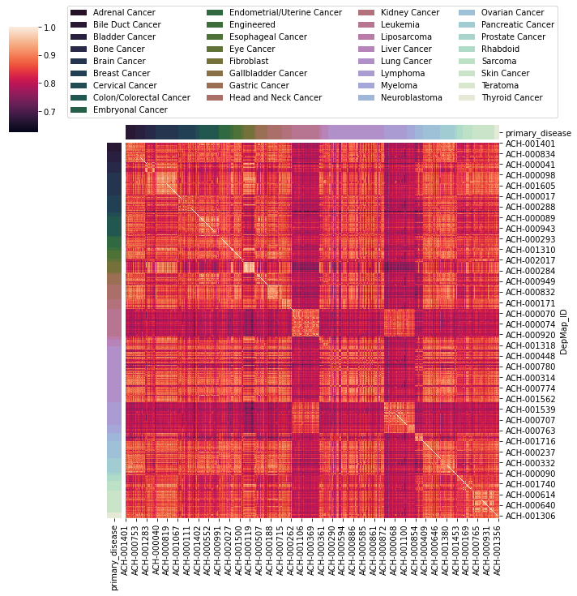

```python
df_corr_disease_ = df_corr_disease.reset_index()
df_corr_disease_ = df_corr_disease_.rename(columns={'index': 'DepMap_ID'}) #change the column name to make the two files consistent

df_corr_disease_concat = pd.merge( df_corr_disease_, df_genes_sorted_disease_stage[['primary_disease','primary_or_metastasis','DepMap_ID']], on=['DepMap_ID'], how='left' )

df_corr_disease_concat = df_corr_disease_concat. set_index('DepMap_ID')
display(df_corr_disease_concat)



%matplotlib inline
import matplotlib.pyplot as plt

#----- Heatmap and ClusterMap for Correlation Matrix ------
diseases = df_corr_disease_concat.loc[:,'primary_disease']

network_pal = sns.cubehelix_palette(len(diseases.unique()),
                                    light=.9, dark=.1, reverse=True,
                                    start=1, rot=-2)
network_lut = dict(zip(map(str, diseases.unique()), network_pal))
# Convert the palette to vectors that will be drawn on the side of the matrix
network_labels = diseases
network_colors = pd.Series(network_labels, index=df_corr_disease_concat.columns).map(network_lut)
# Create a custom colormap for the heatmap values
cmap = sns.diverging_palette(h_neg=210, h_pos=350, s=90, l=30, as_cmap=True)

# heatmap (data is shown in the original order : in order of primary diseases)
print("Correlation heatmap with disease labels:\n")
heatmap = sns.clustermap(df_corr_disease_concat.iloc[:,:-2]
                             ,row_cluster=False, col_cluster=False
                             ,row_colors=network_colors, col_colors=network_colors) # draw heatmap with a color bar showing disease groups
# Draw the legend bar for the diseases
for label in network_labels.unique():
    heatmap.ax_col_dendrogram.bar(0, 0, color=network_lut[label],
                            label=label, linewidth=0)
heatmap.ax_col_dendrogram.legend(loc="lower center", ncol=4)

plt.show()
```

In the correlation heatmap above, the square-shaped patterns of high correlation near the diagonal supports **hypothesis 1**. The highest correlations can be seen between subjects from the same disease group. This could be a cue to using disease type as a categorical variable and studying it more in depth.

### Analyzing Cancer Stage

Now, let's make similar plots to find the pairwise cell line correlations and find patterns based on the *stage* of cancer.

Plot the correlation heatmap:

```
Correlation heatmap with stage labels:
```

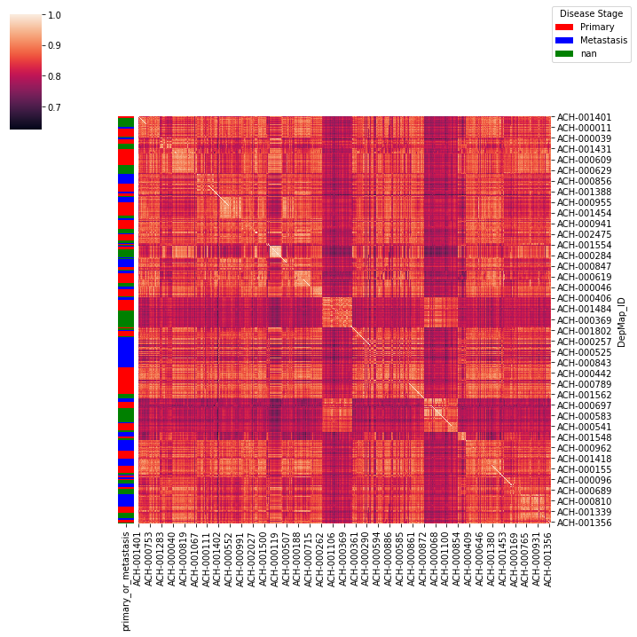

```python
df_corr_stage_concat = df_corr_disease_concat

#----- ClusterMap ------
stages = df_corr_stage_concat.loc[:,'primary_or_metastasis']

lut = dict(zip(stages.unique(), "rbg"))
row_colors = stages.map(lut)

from matplotlib.patches import Patch
handles = [Patch(facecolor=lut[name]) for name in lut]

# heatmap (data is shown in the original order : in order of primary diseases)
print("Correlation heatmap with stage labels:\n")
heatmap = sns.clustermap(df_corr_stage_concat.iloc[:,:-2]
                             ,row_cluster=False, col_cluster=False
                             ,row_colors=row_colors) # draw heatmap with hierarchical clustering and a color bar showing disease groups
plt.legend(handles, lut, title='Disease Stage',
           bbox_to_anchor=(1, 1), bbox_transform=plt.gcf().transFigure, loc='upper right')


plt.show()
```

Judging from the heatmap above, there are no significant patterns of high correlation among patients that are in the same cancer progression stage (even among the ones with the same disease). Therefore, at least with the present dataset (which contains no information of cancer stage for some patients (NaN)), disease type seems to be a better choice to study when it comes to cell line classification based on genomic data.

# Dimensionality Reduction with PCA

The CCLE dataset contains more than 19000 features (genes); however, not all gene expressions are important. Through PCA, we can find the most variant components of the data, as they most likely determine the properties of the cell lines (such as their disease type or stage of cancer). This will reduce our data to a subset of dimensions that contains the highest amount of (meaningful) information. We should be aware, however, that the resulting principal components obtained from this analysis are not semantically meaningful (they are not *genes*). Nonetheless, we can certainly use them in subsequent analyses.

```python
from sklearn import preprocessing
from sklearn.decomposition import PCA
from sklearn.cluster import KMeans
```

```python
# separate the rows that contain NaNs (ensures correct ordering of data)

na_free = df_gene_stage_disease.iloc[:,1:-2].dropna()
only_na = df_gene_stage_disease.iloc[:,1:-2][~df_gene_stage_disease.iloc[:,1:-2].index.isin(na_free.index)]


# take out the corresponding NaN-containing rows from info, to make PCA results and info consistent

df_gene_stage_disease_nafree = df_gene_stage_disease.drop(only_na.index).reset_index().drop(columns=['index'])
```

First, let's try reducing our data to two dimensions:

```python
# perform PCA and reduce data into 2 dimensions

n=2
pcs = ['PC'+str(x) for x in range(n)]
pca = PCA(n_components=n,max_iter=20,n_jobs=4)
principalComponents = pca.fit_transform(na_free)
principalDf = pd.DataFrame(data = principalComponents, columns = pcs)
principalDfConcat2 = pd.concat([df_gene_stage_disease_nafree['DepMap_ID'],principalDf,df_gene_stage_disease_nafree['primary_disease']],axis=1)
display(principalDfConcat2)
```

|  | DepMap_ID | PC0 | PC1 | primary_disease |
| --- | --- | --- | --- | --- |
| 0 | ACH-000001 | -31.015428 | -11.065545 | Ovarian Cancer |
| 1 | ACH-000002 | 113.321337 | -25.906754 | Leukemia |
| 2 | ACH-000003 | -17.001841 | -46.082418 | Colon/Colorectal Cancer |
| 3 | ACH-000004 | 82.018682 | 15.838379 | Leukemia |
| 4 | ACH-000005 | 75.360940 | 24.961189 | Leukemia |
| ... | ... | ... | ... | ... |
| 1369 | ACH-002475 | 34.743389 | 27.722289 | Engineered |
| 1370 | ACH-002508 | -18.960837 | 34.804632 | Skin Cancer |
| 1371 | ACH-002509 | -21.894764 | 59.697764 | Skin Cancer |
| 1372 | ACH-002510 | 11.158104 | 21.992468 | Skin Cancer |
| 1373 | ACH-002511 | -34.189940 | 50.985813 | Skin Cancer |

1374 rows × 4 columns

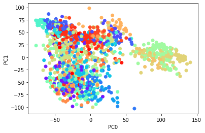

```python
# plot the 2-dimensional result
# make a color list for different diseases and plot the PCs

%matplotlib inline
import matplotlib

disease_list = list(np.unique(principalDfConcat2['primary_disease']))
colors = np.linspace(0,1,num = len(disease_list))*3+1.5

cmap = plt.cm.rainbow
norm = matplotlib.colors.Normalize(vmin=1.5, vmax=4.5)
colors_rgba = cmap(norm(colors))
color_tuples= [tuple(x) for x in colors_rgba.tolist()]
color_dict = dict(zip(disease_list, color_tuples))

c= [color_dict[principalDfConcat2.loc[subject[0],'primary_disease']] for subject in principalDfConcat2.iterrows()]

fig, ax = plt.subplots(1,1)
ax.scatter(principalDfConcat2['PC0'],principalDfConcat2['PC1'], c = c)
ax.set_xlabel('PC0')
ax.set_ylabel('PC1')
plt.show()
```

which is a two-dimensional representation of the data. We observe that the two principal components are capturing big changes in expressions for most types of cancer. While this data representation does not separate the different disease types from one another completely, it is showing a certain pattern where a few diseases are found more prominently in certain spots on the 2-D plane.

When the first two PCs do not capture the majority of the variance, it may be helpful to generate 3-dimensional as well as additional two-dimensional PCA plots displaying other PCs. In this way, a PCA plot may also help to visualize grouping among replicates and aid in identifying technical or biological outliers.

Here, I try 3 and 12 principal components. The three-dimensional visualization could help us check if the diseases get separated in a higher dimension:

```python
n=3
pcs = ['PC'+str(x) for x in range(n)]
pca = SparsePCA(n_components=n,max_iter=20,n_jobs=4)
principalComponents = pca.fit_transform(na_free)
principalDf = pd.DataFrame(data = principalComponents, columns = pcs)
principalDfConcat3 = pd.concat([df_gene_stage_disease_nafree['DepMap_ID'],principalDf,df_gene_stage_disease_nafree['primary_disease']],axis=1)
display(principalDfConcat3)
```

|  | DepMap_ID | PC0 | PC1 | PC2 | primary_disease |
| --- | --- | --- | --- | --- | --- |
| 0 | ACH-000001 | -33.386306 | -10.072655 | -43.113755 | Ovarian Cancer |
| 1 | ACH-000002 | 116.495459 | -28.006309 | 63.246299 | Leukemia |
| 2 | ACH-000003 | -18.118754 | -45.868202 | -14.362581 | Colon/Colorectal Cancer |
| 3 | ACH-000004 | 82.119650 | 15.495296 | -1.372635 | Leukemia |
| 4 | ACH-000005 | 74.863161 | 24.952804 | -14.107748 | Leukemia |
| ... | ... | ... | ... | ... | ... |
| 1369 | ACH-002475 | 33.682851 | 27.991906 | -24.407921 | Engineered |
| 1370 | ACH-002508 | -14.875170 | 33.607967 | 72.092975 | Skin Cancer |
| 1371 | ACH-002509 | -21.813916 | 60.216563 | -7.484529 | Skin Cancer |
| 1372 | ACH-002510 | 13.893829 | 20.920993 | 49.205567 | Skin Cancer |
| 1373 | ACH-002511 | -32.668020 | 50.963683 | 21.255404 | Skin Cancer |

1374 rows × 5 columns

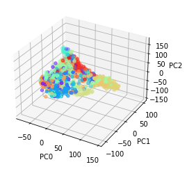

```python
# ** The plot from this cell should be a pop-out, interactive window
#    if the interactive plot doesn't work, uncomment the magic command "%matplotlib inline"

#%matplotlib ipympl
%matplotlib inline

import matplotlib
import matplotlib.pyplot as plt
from mpl_toolkits.mplot3d import Axes3D

# make a color list for different diseases and plot the 3-dim data representation

disease_list = list(np.unique(principalDfConcat3['primary_disease']))
"""
resulting:
disease_list = ['Ovarian Cancer', 'Leukemia', 'Colon/Colorectal Cancer', 'Skin Cancer',
 'Lung Cancer', 'Bladder Cancer', 'Kidney Cancer', 'Breast Cancer',
 'Pancreatic Cancer', 'Myeloma', 'Brain Cancer', 'Sarcoma', 'Lymphoma',
 'Bone Cancer', 'Fibroblast', 'Gastric Cancer', 'Engineered', 'Thyroid Cancer',
 'Neuroblastoma', 'Prostate Cancer', 'Rhabdoid', 'Gallbladder Cancer',
 'Endometrial/Uterine Cancer', 'Head and Neck Cancer', 'Bile Duct Cancer',
 'Esophageal Cancer', 'Liver Cancer', 'Cervical Cancer', 'Unknown',
 'Eye Cancer', 'Adrenal Cancer', 'Liposarcoma', 'Embryonal Cancer', 'Teratoma',
 'Non-Cancerous']
"""
colors = np.linspace(0,1,num = len(disease_list))*3+1.5

cmap = plt.cm.rainbow
norm = matplotlib.colors.Normalize(vmin=1.5, vmax=4.5)
colors_rgba = cmap(norm(colors))
color_tuples= [tuple(x) for x in colors_rgba.tolist()]
color_dict = dict(zip(disease_list, color_tuples))

c= [color_dict[principalDfConcat3.loc[subject[0],'primary_disease']] for subject in principalDfConcat3.iterrows()]
fig = plt.figure()
ax = fig.add_subplot(111, projection='3d')
ax.scatter(principalDfConcat3['PC0'],principalDfConcat3['PC1'],principalDfConcat3['PC2'], c = c)
ax.set_xlabel('PC0')
ax.set_ylabel('PC1')
ax.set_zlabel('PC2')
#print(matplotlib.get_backend())
plt.show()
```

Better! But we still need more dimensions to separate out our many different cancer types:

```python
n=12
pcs = ['PC'+str(x) for x in range(n)]
pca = PCA(n_components=n)#,max_iter=20,n_jobs=4)
principalComponents = pca.fit_transform(na_free)
principalDf = pd.DataFrame(data = principalComponents, columns = pcs)
principalDfConcat12 = pd.concat([df_gene_stage_disease_nafree['DepMap_ID'],principalDf,df_gene_stage_disease_nafree['primary_disease']],axis=1)
display(principalDfConcat12)
```

|  | DepMap_ID | PC0 | PC1 | PC2 | PC3 | PC4 | PC5 | PC6 | PC7 | PC8 | PC9 | PC10 | PC11 | primary_disease |
| --- | --- | --- | --- | --- | --- | --- | --- | --- | --- | --- | --- | --- | --- | --- |
| 0 | ACH-000001 | -31.529356 | 7.700233 | -46.022780 | 6.148457 | -19.646644 | -2.286793 | -1.058360 | -13.956579 | 12.917853 | 7.572868 | 25.383013 | 18.465639 | Ovarian Cancer |
| 1 | ACH-000002 | 114.138973 | 32.902665 | 63.357646 | 12.184324 | 2.504582 | 10.038136 | -14.498750 | -31.081379 | -9.923456 | 21.992936 | -25.089102 | -11.530060 | Leukemia |
| 2 | ACH-000003 | -18.156523 | 45.491790 | -22.462831 | 9.742845 | 27.517639 | 0.005691 | -20.036910 | -2.118484 | -6.767890 | 3.015318 | 6.186406 | 18.893148 | Colon/Colorectal Cancer |
| 3 | ACH-000004 | 83.810391 | -15.408422 | 2.821778 | -39.667842 | 6.019946 | 10.694450 | -9.620434 | -33.356993 | -27.949655 | 63.204303 | 1.219184 | -29.978966 | Leukemia |
| 4 | ACH-000005 | 77.267496 | -25.980666 | -8.955828 | -43.632662 | 8.266061 | -12.239055 | -0.820157 | -13.615143 | -39.658829 | 65.718775 | 14.948509 | -25.454481 | Leukemia |
| ... | ... | ... | ... | ... | ... | ... | ... | ... | ... | ... | ... | ... | ... | ... |
| 1369 | ACH-002475 | 35.894276 | -27.888829 | -18.225453 | 45.102629 | 4.941377 | -29.910875 | 0.065900 | 4.026658 | -14.832932 | 15.820446 | 20.487410 | 3.098895 | Engineered |
| 1370 | ACH-002508 | -18.627873 | -30.303474 | 77.895315 | 14.240525 | -0.489569 | -1.828621 | 0.190541 | 14.282170 | -15.566039 | 0.906939 | 8.350781 | -8.534684 | Skin Cancer |
| 1371 | ACH-002509 | -21.095976 | -60.671248 | 1.758604 | 14.165505 | 13.885264 | 26.559772 | 40.406429 | 2.133260 | -6.992978 | 23.919889 | 12.809216 | 5.194856 | Skin Cancer |
| 1372 | ACH-002510 | 10.880149 | -17.687376 | 54.301210 | 50.472848 | 54.937614 | 27.372853 | 73.361996 | -1.547270 | 5.414237 | 11.329050 | 17.730989 | 0.925182 | Skin Cancer |
| 1373 | ACH-002511 | -33.791214 | -50.348383 | 28.784299 | -0.151208 | 10.044540 | 14.536796 | 44.912840 | 17.576389 | -6.913629 | 15.344557 | 18.660076 | 14.376597 | Skin Cancer |

1374 rows × 14 columns

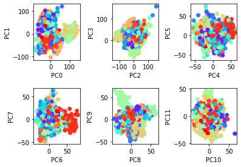

```python
# make a color list for different diseases and plot the PCs
%matplotlib inline
import matplotlib

disease_list = list(np.unique(principalDfConcat12['primary_disease']))

colors = np.linspace(0,1,num = len(disease_list))*3+1.5

cmap = plt.cm.rainbow
norm = matplotlib.colors.Normalize(vmin=1.5, vmax=4.5)
colors_rgba = cmap(norm(colors))
color_tuples= [tuple(x) for x in colors_rgba.tolist()]
color_dict = dict(zip(disease_list, color_tuples))

c= [color_dict[principalDfConcat12.loc[subject[0],'primary_disease']] for subject in principalDfConcat12.iterrows()]

fig, ax = plt.subplots(2,3)
ax[0,0].scatter(principalDfConcat12['PC0'],principalDfConcat12['PC1'], c = c)
ax[0,0].set_xlabel('PC0')
ax[0,0].set_ylabel('PC1')
ax[0,1].scatter(principalDfConcat12['PC2'],principalDfConcat12['PC3'], c = c)
ax[0,1].set_xlabel('PC2')
ax[0,1].set_ylabel('PC3')
ax[0,2].scatter(principalDfConcat12['PC4'],principalDfConcat12['PC5'], c = c)
ax[0,2].set_xlabel('PC4')
ax[0,2].set_ylabel('PC5')
ax[1,0].scatter(principalDfConcat12['PC6'],principalDfConcat12['PC7'], c = c)
ax[1,0].set_xlabel('PC6')
ax[1,0].set_ylabel('PC7')
ax[1,1].scatter(principalDfConcat12['PC8'],principalDfConcat12['PC9'], c = c)
ax[1,1].set_xlabel('PC8')
ax[1,1].set_ylabel('PC9')
ax[1,2].scatter(principalDfConcat12['PC10'],principalDfConcat12['PC11'], c = c)
ax[1,2].set_xlabel('PC10')
ax[1,2].set_ylabel('PC11')
plt.subplots_adjust(left=0.125, bottom=0.1, right=0.9, top=0.9, wspace=0.7, hspace=0.5)
plt.show()
```

The major variances of data for all different *types* of cancer, is reflected in the above plots, where all diseases are quite spread out. As we increase the number of PCs, these variations (the range of changes in the data) get smaller, which can help us remove outliers or noise by finding non-variant components. The first four components seem to contain the highest variance as could be seen in the first two of the plots above.

As observed in the plots above, some of the diseases that are not separated in one pair of dimensions, seem more concentrated and secluded in some other plots. Hence I assumed that the disease groups are separated in the higher (12) dimension. Twelve dimensions seems to be a reasonable number of features for the experiments of the following sections.

# Clustering (K-Means)

Now that we have reduced our data to a smaller version with most informative dimensions, performing a clustering algorithm on the resulting data could help us test **hypothesis 2**. K-Means clustering is a popular algorithm that segments data into K groups, based on the distance between datapoints. Here, I use a scikit-learn K-Means module to perform this algorithm on the 12-dimensional representation of the genetic expression data. The visualization of 12 dimensions all in one plot is not possible, so we cannot be sure whether the dimensionality-reduced datapoints are "separated" based on the true primary diseases. Assuming that this is the case, we will take a statistical approach and compute what portion of a clustered data chunk is "correctly grouped" via the K-Means module.

```python
# build clustering model and run k-means
principalDf_ID_values = principalDfConcat12.drop(columns='primary_disease')
k = len(disease_list)
print("number of clusters = ",k)
kmeans = KMeans(n_clusters=k, random_state=0).fit(principalDf_ID_values.set_index('DepMap_ID')) # 34 clusters because we have 34 diseases
labels = kmeans.labels_

# add a column to the data to show the cluster category
principalDfConcat12['cluster'] = labels
display(principalDfConcat12)
```

```
number of clusters =  33
```

|  | DepMap_ID | PC0 | PC1 | PC2 | PC3 | PC4 | PC5 | PC6 | PC7 | PC8 | PC9 | PC10 | PC11 | primary_disease | cluster |
| --- | --- | --- | --- | --- | --- | --- | --- | --- | --- | --- | --- | --- | --- | --- | --- |
| 0 | ACH-000001 | -31.529356 | 7.700233 | -46.022780 | 6.148457 | -19.646644 | -2.286793 | -1.058360 | -13.956579 | 12.917853 | 7.572868 | 25.383013 | 18.465639 | Ovarian Cancer | 6 |
| 1 | ACH-000002 | 114.138973 | 32.902665 | 63.357646 | 12.184324 | 2.504582 | 10.038136 | -14.498750 | -31.081379 | -9.923456 | 21.992936 | -25.089102 | -11.530060 | Leukemia | 14 |
| 2 | ACH-000003 | -18.156523 | 45.491790 | -22.462831 | 9.742845 | 27.517639 | 0.005691 | -20.036910 | -2.118484 | -6.767890 | 3.015318 | 6.186406 | 18.893148 | Colon/Colorectal Cancer | 23 |
| 3 | ACH-000004 | 83.810391 | -15.408422 | 2.821778 | -39.667842 | 6.019946 | 10.694450 | -9.620434 | -33.356993 | -27.949655 | 63.204303 | 1.219184 | -29.978966 | Leukemia | 9 |
| 4 | ACH-000005 | 77.267496 | -25.980666 | -8.955828 | -43.632662 | 8.266061 | -12.239055 | -0.820157 | -13.615143 | -39.658829 | 65.718775 | 14.948509 | -25.454481 | Leukemia | 9 |
| ... | ... | ... | ... | ... | ... | ... | ... | ... | ... | ... | ... | ... | ... | ... | ... |
| 1369 | ACH-002475 | 35.894276 | -27.888829 | -18.225453 | 45.102629 | 4.941377 | -29.910875 | 0.065900 | 4.026658 | -14.832932 | 15.820446 | 20.487410 | 3.098895 | Engineered | 15 |
| 1370 | ACH-002508 | -18.627873 | -30.303474 | 77.895315 | 14.240525 | -0.489569 | -1.828621 | 0.190541 | 14.282170 | -15.566039 | 0.906939 | 8.350781 | -8.534684 | Skin Cancer | 17 |
| 1371 | ACH-002509 | -21.095976 | -60.671248 | 1.758604 | 14.165505 | 13.885264 | 26.559772 | 40.406429 | 2.133260 | -6.992978 | 23.919889 | 12.809216 | 5.194856 | Skin Cancer | 0 |
| 1372 | ACH-002510 | 10.880149 | -17.687376 | 54.301210 | 50.472848 | 54.937614 | 27.372853 | 73.361996 | -1.547270 | 5.414237 | 11.329050 | 17.730989 | 0.925182 | Skin Cancer | 24 |
| 1373 | ACH-002511 | -33.791214 | -50.348383 | 28.784299 | -0.151208 | 10.044540 | 14.536796 | 44.912840 | 17.576389 | -6.913629 | 15.344557 | 18.660076 | 14.376597 | Skin Cancer | 4 |

1374 rows × 15 columns

We now have the cluster assigned to each cell line. The next step is checking the similarity between this grouping and the true disease labels:

```python
# check for similarity
print("*** number of instances *** \n")
counts = principalDfConcat12.reset_index().groupby('primary_disease')['cluster'].value_counts()
display(counts[1:50])
display(counts[120:150])
print("\n *** average *** \n ")
display((counts/principalDfConcat12.shape[0])[120:150])
print('maximum average value: ',(counts/principalDfConcat12.shape[0]).max())
```

```
*** number of instances ***
```

```
primary_disease   cluster
Bile Duct Cancer  1          12
                  10          4
                  13          4
                  20          3
                  25          2
                  28          2
                  4           1
                  5           1
                  11          1
                  12          1
                  17          1
                  21          1
                  23          1
                  27          1
```

[output cut: 36 more lines]

```
primary_disease       cluster
Gallbladder Cancer    13          1
                      17          1
                      25          1
Gastric Cancer        23         16
                      6           3
                      12          3
                      16          3
                      25          3
                      21          2
                      22          2
                      28          2
                      3           1
                      7           1
                      10          1
```

[output cut: 17 more lines]

```
 *** average ***
```

```
primary_disease       cluster
Gallbladder Cancer    13         0.000728
                      17         0.000728
                      25         0.000728
Gastric Cancer        23         0.011645
                      6          0.002183
                      12         0.002183
                      16         0.002183
                      25         0.002183
                      21         0.001456
                      22         0.001456
                      28         0.001456
                      3          0.000728
                      7          0.000728
                      10         0.000728
```

[output cut: 17 more lines]

```
maximum average value:  0.03566229985443959
```

# Classifying Cell Lines

## into different diseases, based on genetic features

Now that we have the most informative principal components and have found the best way of categorizing our cell lines (cancer type), we can take a supervised approach for classification. Our class labels are the primary disease names (33 diseases = 33 classes), and the principal components are input features to the classification model.

```python
dataset = principalDfConcat12.sample(frac=1).drop(columns='DepMap_ID') # shuffle data
display(dataset)
```

|  | PC0 | PC1 | PC2 | PC3 | PC4 | PC5 | PC6 | PC7 | PC8 | PC9 | PC10 | PC11 | primary_disease | cluster |
| --- | --- | --- | --- | --- | --- | --- | --- | --- | --- | --- | --- | --- | --- | --- |
| 426 | 7.941838 | -17.240009 | 19.279468 | -6.811925 | 26.971820 | -41.757643 | -8.530372 | -10.803193 | -1.894316 | -1.354661 | -21.833998 | -17.397286 | Ovarian Cancer | 16 |
| 182 | -66.471344 | -73.485608 | 53.404980 | -15.505440 | -4.493471 | 24.348694 | -28.654714 | 5.648896 | -30.068710 | -27.212166 | -12.407442 | -3.337695 | Fibroblast | 18 |
| 1124 | 23.082643 | -29.743066 | -19.237076 | 43.271581 | 12.903703 | -34.743738 | -8.514041 | -21.904482 | 4.207127 | -9.054803 | 23.845761 | -22.685645 | Adrenal Cancer | 21 |
| 840 | -34.583752 | 39.931896 | -38.632726 | -25.215449 | -18.701823 | -1.888201 | 13.722604 | -12.697892 | 0.126039 | -13.598530 | 19.347741 | 1.612163 | Breast Cancer | 12 |
| 648 | -39.593012 | -57.207678 | 20.353141 | -2.288075 | 0.723954 | -13.014532 | -13.029465 | -1.734289 | -3.974625 | -18.888312 | -18.791996 | 10.195525 | Brain Cancer | 5 |
| ... | ... | ... | ... | ... | ... | ... | ... | ... | ... | ... | ... | ... | ... | ... |
| 282 | -62.150880 | -69.241946 | 49.603055 | -20.275721 | 1.081686 | 19.402760 | -25.040054 | 1.641084 | -27.713665 | -23.238090 | -13.384478 | -4.382788 | Fibroblast | 18 |
| 414 | -35.611637 | 71.614859 | -17.803231 | -37.544801 | 9.134029 | -16.430515 | -1.494923 | 16.958116 | -14.181576 | 9.098814 | -15.184710 | 3.632473 | Pancreatic Cancer | 1 |
| 51 | 63.343422 | -0.240553 | 26.228411 | -54.005710 | 1.253126 | 12.194084 | 7.294522 | 0.399523 | 17.319578 | 5.481788 | -3.135920 | -35.814542 | Lymphoma | 26 |
| 594 | 10.575065 | 3.819031 | 9.800445 | 20.319524 | 23.545460 | -27.339069 | -19.948625 | -36.914454 | 9.736000 | -13.594137 | -22.852761 | -7.109607 | Pancreatic Cancer | 21 |
| 1363 | -32.769075 | -35.515169 | 69.029897 | 16.726882 | 16.270162 | 11.418064 | 20.061715 | 5.926567 | -1.451966 | -8.526839 | -11.993651 | -1.692652 | Skin Cancer | 17 |

1374 rows × 14 columns

We split the dataset into train and test sets, and encode the labels into integers that could be understood by our machine learning models:

```python
import collections
from sklearn.preprocessing import LabelEncoder

le = LabelEncoder()

x = dataset.iloc[:,:-2].to_numpy()
y = dataset['primary_disease']

y_encoded = le.fit_transform(y) # encode the training labels into integer values

y_categories = pd.DataFrame()
y_categories['primary_disease'] = dataset['primary_disease']
categories = dict(zip(y_encoded,dataset['primary_disease']))
ordered_categories = collections.OrderedDict(sorted(categories.items()))

# train-test split
x_train = x[:1000]
y_train = y_encoded[:1000]

x_test = x[1000:]
y_test = y_encoded[1000:]

print("training set shapes: input = {} labels = {}".format(x_train.shape,y_train.shape))
print("test set shapes: input = {} labels = {}".format(x_test.shape,y_test.shape))
```

```
training set shapes: input = (1000, 12) labels = (1000,)
test set shapes: input = (374, 12) labels = (374,)
```

To have a better idea of the quality of our data, I tried three different classifiers: a decision tree, a random forest, and a SVM model, all trained on the same train-test splits of the dataset. The hyperparameters were tuned and the following values seemed to work best:

```python
from sklearn import datasets
from sklearn.multiclass import OneVsRestClassifier
from sklearn.svm import SVC
from sklearn.metrics import accuracy_score, classification_report, confusion_matrix
from sklearn.ensemble import RandomForestClassifier
from sklearn.tree import DecisionTreeClassifier

y_pred = DecisionTreeClassifier(criterion = 'entropy', max_depth=7).fit(x_train, y_train).predict(x_test)
y_pred_train = DecisionTreeClassifier(criterion = 'entropy', max_depth=7).fit(x_train, y_train).predict(x_train)

# Evaluate the model
print("*** Decision Tree ***")
print(f"Train Set Accuracy : {accuracy_score(y_train, y_pred_train) * 100} %\n\n")
print(f"Test Set Accuracy : {accuracy_score(y_test, y_pred) * 100} %\n\n")

y_pred = RandomForestClassifier(n_estimators = 30, criterion = 'entropy', max_depth=7, random_state=0).fit(x_train, y_train).predict(x_test)
y_pred_train = RandomForestClassifier(n_estimators = 30, criterion = 'entropy', max_depth=7, random_state=0).fit(x_train, y_train).predict(x_train)

# Evaluate the model
print("*** Random Forest ***")
print(f"Train Set Accuracy : {accuracy_score(y_train, y_pred_train) * 100} %\n\n")
print(f"Test Set Accuracy : {accuracy_score(y_test, y_pred) * 100} %\n\n")

y_pred = OneVsRestClassifier(SVC(gamma = 'scale', kernel = 'rbf', degree = 3, random_state=0)).fit(x_train, y_train).predict(x_test)
y_pred_train = OneVsRestClassifier(SVC(gamma = 'scale', kernel = 'rbf', degree = 3, random_state=0)).fit(x_train, y_train).predict(x_train)

print("*** One VS All SVM ***")
print(f"Train Set Accuracy : {accuracy_score(y_train, y_pred_train) * 100} %\n\n")
print(f"Test Set Accuracy : {accuracy_score(y_test, y_pred) * 100} %\n\n")
```

```
*** Decision Tree ***
Train Set Accuracy : 67.10000000000001 %


Test Set Accuracy : 51.06951871657755 %


*** Random Forest ***
Train Set Accuracy : 82.39999999999999 %


Test Set Accuracy : 60.16042780748663 %


*** One VS All SVM ***
Train Set Accuracy : 74.1 %


Test Set Accuracy : 62.299465240641716 %
```

The SVM model seems to work better on our test set. However, the accuracy is not high enough in general. One possible issue could be that our dataset is imbalanced, or the number of samples is too low for the model to distinguish so many classes (33 classes) from one another. I created the confusion matrix for the SVM model and printed the number of instances for each disease in the dataset, to test these hypotheses:

```
OrderedDict([(0, 'Adrenal Cancer'), (1, 'Bile Duct Cancer'), (2, 'Bladder Cancer'), (3, 'Bone Cancer'), (4, 'Brain Cancer'), (5, 'Breast Cancer'), (6, 'Cervical Cancer'), (7, 'Colon/Colorectal Cancer'), (8, 'Embryonal Cancer'), (9, 'Endometrial/Uterine Cancer'), (10, 'Engineered'), (11, 'Esophageal …
```

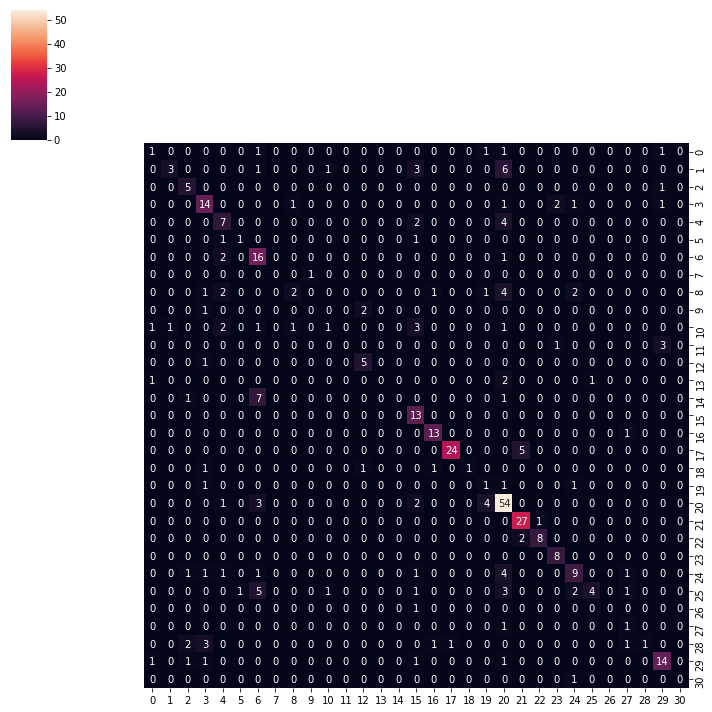

```python
# View confusion matrix for test data and predictions
conf = confusion_matrix(y_test, y_pred)
heatmap = sns.clustermap(conf, row_cluster=False, col_cluster=False
                         ,linewidths=0,annot=True)
print(ordered_categories)
```

```python
counts = principalDfConcat12['primary_disease'].value_counts()
display(counts)
```

```
Lung Cancer                   206
Leukemia                      100
Brain Cancer                   84
Lymphoma                       82
Skin Cancer                    80
Colon/Colorectal Cancer        71
Ovarian Cancer                 64
Breast Cancer                  61
Head and Neck Cancer           53
Pancreatic Cancer              52
Gastric Cancer                 40
Bone Cancer                    39
Fibroblast                     39
Endometrial/Uterine Cancer     39
Kidney Cancer                  37
Sarcoma                        36
Bladder Cancer                 36
Bile Duct Cancer               35
Esophageal Cancer              31
Myeloma                        31
Neuroblastoma                  28
Liver Cancer                   24
Rhabdoid                       20
Cervical Cancer                17
Thyroid Cancer                 17
Engineered                     13
Prostate Cancer                11
Liposarcoma                    10
Eye Cancer                      9
Gallbladder Cancer              6
Teratoma                        1
Adrenal Cancer                  1
Embryonal Cancer                1
Name: primary_disease, dtype: int64
```

While the confusion matrix looks good, the number of subject with different primary diseases are imbalanced. Let's see if reducing the dataset to a subset that contains some of the more balanced diseases would help the classifier:

```python
# obtain a more balanced set of the data, and perform classification

sub_data = principalDfConcat12.loc[principalDfConcat12['primary_disease'].isin(['Brain Cancer'
                                                                                ,'Lymphoma'
                                                                                ,'Skin Cancer'
                                                                                ,'Colon/Colorectal Cancer'
                                                                                ,'Ovarian Cancer'
                                                                                ,'Breast Cancer'])]
display(sub_data)

dataset = sub_data.sample(frac=1).drop(columns='DepMap_ID') # shuffle data

le = LabelEncoder()

x = dataset.iloc[:,:-2].to_numpy()
y = dataset['primary_disease']

y_encoded = le.fit_transform(y) # encode the training labels into integer values

# train-test split
x_train = x[:190]
y_train = y_encoded[:190]

x_test = x[190:]
y_test = y_encoded[190:]

print("training set shapes: input = {} labels = {}".format(x_train.shape,y_train.shape))
print("test set shapes: input = {} labels = {}\n\n".format(x_test.shape,y_test.shape))


y_pred = DecisionTreeClassifier(criterion = 'entropy', max_depth=10).fit(x_train, y_train).predict(x_test)
y_pred_train = DecisionTreeClassifier(criterion = 'entropy', max_depth=10).fit(x_train, y_train).predict(x_train)

# Evaluate the model
print("*** Decision Tree ***")
print(f"Train Set Accuracy : {accuracy_score(y_train, y_pred_train) * 100} %\n\n")
print(f"Test Set Accuracy : {accuracy_score(y_test, y_pred) * 100} %\n\n")

y_pred = RandomForestClassifier(n_estimators = 30, criterion = 'entropy', max_depth=10, random_state=0).fit(x_train, y_train).predict(x_test)
y_pred_train = RandomForestClassifier(n_estimators = 30, criterion = 'entropy', max_depth=10, random_state=0).fit(x_train, y_train).predict(x_train)

# Evaluate the model
print("*** Random Forest ***")
print(f"Train Set Accuracy : {accuracy_score(y_train, y_pred_train) * 100} %\n\n")
print(f"Test Set Accuracy : {accuracy_score(y_test, y_pred) * 100} %\n\n")

y_pred = OneVsRestClassifier(SVC(gamma = 'scale', kernel = 'rbf', degree = 3, random_state=0)).fit(x_train, y_train).predict(x_test)
y_pred_train = OneVsRestClassifier(SVC(gamma = 'scale', kernel = 'rbf', degree = 3, random_state=0)).fit(x_train, y_train).predict(x_train)

print("*** One VS All SVM ***")
print(f"Train Set Accuracy : {accuracy_score(y_train, y_pred_train) * 100} %\n\n")
print(f"Test Set Accuracy : {accuracy_score(y_test, y_pred) * 100} %\n\n")
```

|  | DepMap_ID | PC0 | PC1 | PC2 | PC3 | PC4 | PC5 | PC6 | PC7 | PC8 | PC9 | PC10 | PC11 | primary_disease | cluster |
| --- | --- | --- | --- | --- | --- | --- | --- | --- | --- | --- | --- | --- | --- | --- | --- |
| 0 | ACH-000001 | -31.529356 | 7.700233 | -46.022780 | 6.148457 | -19.646644 | -2.286793 | -1.058360 | -13.956579 | 12.917853 | 7.572868 | 25.383013 | 18.465639 | Ovarian Cancer | 6 |
| 2 | ACH-000003 | -18.156523 | 45.491790 | -22.462831 | 9.742845 | 27.517639 | 0.005691 | -20.036910 | -2.118484 | -6.767890 | 3.015318 | 6.186406 | 18.893148 | Colon/Colorectal Cancer | 23 |
| 6 | ACH-000007 | 9.254506 | 87.815395 | -26.105117 | 1.575311 | 49.085017 | 27.361239 | -26.978001 | 20.793167 | -32.251996 | -5.877005 | -21.915721 | 16.000904 | Colon/Colorectal Cancer | 23 |
| 7 | ACH-000008 | -29.511583 | -44.948864 | 14.891938 | -15.575091 | 46.189561 | 12.864035 | 65.312490 | -5.241648 | 10.886879 | -3.927233 | -21.507252 | 7.855484 | Skin Cancer | 0 |
| 8 | ACH-000009 | -20.769082 | 30.618238 | -45.061557 | -3.056090 | 37.344043 | -15.509482 | -19.929474 | 7.479451 | -18.190285 | 1.834100 | 13.866857 | 19.195345 | Colon/Colorectal Cancer | 23 |
| ... | ... | ... | ... | ... | ... | ... | ... | ... | ... | ... | ... | ... | ... | ... | ... |
| 1363 | ACH-002461 | -32.769075 | -35.515169 | 69.029897 | 16.726882 | 16.270162 | 11.418064 | 20.061715 | 5.926567 | -1.451966 | -8.526839 | -11.993651 | -1.692652 | Skin Cancer | 17 |
| 1370 | ACH-002508 | -18.627873 | -30.303474 | 77.895315 | 14.240525 | -0.489569 | -1.828621 | 0.190541 | 14.282170 | -15.566039 | 0.906939 | 8.350781 | -8.534684 | Skin Cancer | 17 |
| 1371 | ACH-002509 | -21.095976 | -60.671248 | 1.758604 | 14.165505 | 13.885264 | 26.559772 | 40.406429 | 2.133260 | -6.992978 | 23.919889 | 12.809216 | 5.194856 | Skin Cancer | 0 |
| 1372 | ACH-002510 | 10.880149 | -17.687376 | 54.301210 | 50.472848 | 54.937614 | 27.372853 | 73.361996 | -1.547270 | 5.414237 | 11.329050 | 17.730989 | 0.925182 | Skin Cancer | 24 |
| 1373 | ACH-002511 | -33.791214 | -50.348383 | 28.784299 | -0.151208 | 10.044540 | 14.536796 | 44.912840 | 17.576389 | -6.913629 | 15.344557 | 18.660076 | 14.376597 | Skin Cancer | 4 |

442 rows × 15 columns

```
training set shapes: input = (190, 12) labels = (190,)
test set shapes: input = (252, 12) labels = (252,)


*** Decision Tree ***
Train Set Accuracy : 100.0 %


Test Set Accuracy : 76.98412698412699 %


*** Random Forest ***
Train Set Accuracy : 99.47368421052632 %


Test Set Accuracy : 85.71428571428571 %


*** One VS All SVM ***
Train Set Accuracy : 92.10526315789474 %


Test Set Accuracy : 86.5079365079365 %
```

The accuracy increased dramatically! This means that our PCA-resulted features are good enough for our classification purpose, and we only need to care for the balance of the data we use for training the classifers. We should also remember that targetting too many classes could mean that we need more data for training our models. **Hypothesis 2** seems to have been supported by our supervised classification method as well.

# Conclusions

Through the experiments above, the underlying patterns of the CCLE RNA-seq data became a bit more clear to me. It was shown via the correlation matrix that cell lines with a similar disease have higher correlations in terms of genetic expressions. This led me to choose disease type as a potential clustering and classification target, which proved to be effective via practical experiments.

In this project I have attempted an analysis to understand the relationship between gene expressions and disease types and stages. However, there is definitely a lot more to explore in this area, and the expressions could contain clues to help predict the cancer progression, deaths, etc. as well as understand the origin of the disease and trace the history of it, which could also be a guide for developing the appropriate drugs for each subject ahead of time and based on their real needs.